# COMPSCIX 415.2 Homework 6

Chunduri SriKeerthi Chandra

July 17th 2018

### Exercise 1

#### 1Q) What variables are in this data set?

The data-set captures **age**, **smoker** and **outcome**(mortality) variables on women in Whickham.

#### 2Q) How many observations are there and what does each represent?

There are 1314 observations on women in Whickham. Each observation captures the age at the time of first survey, smoker (a factor yes/no), and outcome (mortality) status after 20 years of the first survey.

#### 3Q) Create a table (use the R code below as a guide) and a visualization of the relationship between smoking status and outcome, ignoring age. What do you see? Does it make sense?

```r
(modData <- Whickham %>% count(smoker , outcome))
```

```
## # A tibble: 4 x 3
##   smoker outcome     n
##   <fct>  <fct>   <int>
## 1 No     Alive     502
## 2 No     Dead      230
## 3 Yes    Alive     443
## 4 Yes    Dead      139
```

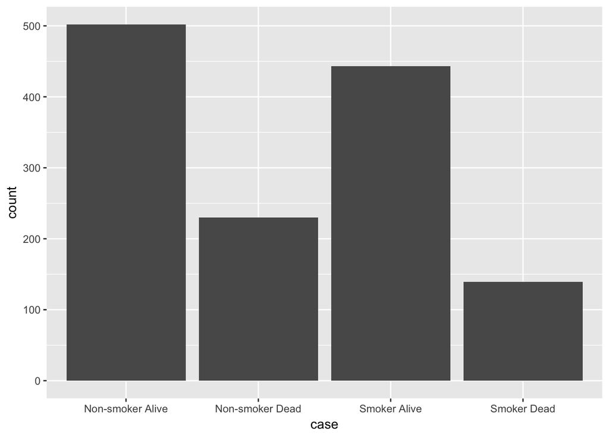

```r
modData %>%
  mutate(case = case_when(smoker == 'No' & outcome == 'Alive' ~ 'Non-smoker Alive',
                         smoker == 'Yes' & outcome == 'Alive' ~ 'Smoker Alive',
                         smoker == 'No' & outcome == 'Dead' ~ 'Non-smoker Dead',
                         smoker == 'Yes' & outcome == 'Dead' ~ 'Smoker Dead')) %>%
   ggplot(mapping = aes(x = case, weight = n)) + geom_bar()
```

It doesn’t make sense. The data shows that more number of non-smokers are dead compared to smokers.

#### 4Q) Recode the age variable into an ordered factor with three categories: age <= 44, age > 44 & age <= 64, and age > 64. Now, recreate visualization from above, but facet on your new age factor. What do you see? Does it make sense?

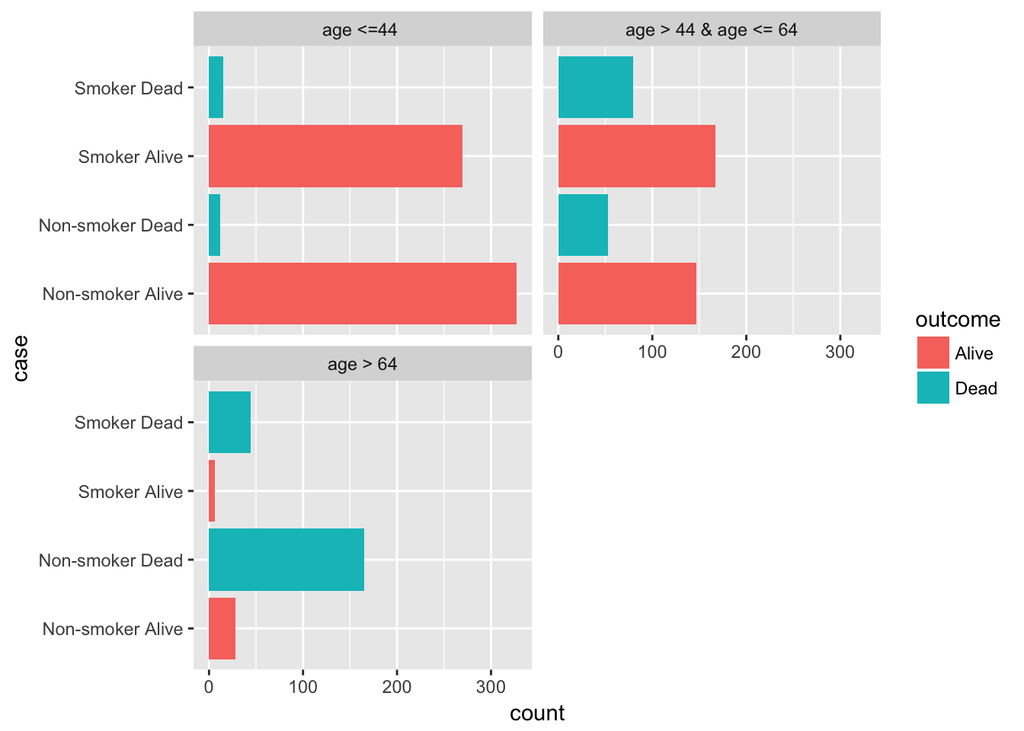

```r
Whickham %>%
  mutate( age_grp = case_when(age <= 44 ~ 'age <=44 ',
                              age > 44 & age <= 64 ~ 'age > 44 & age <= 64',
                              age > 64 ~ 'age > 64')) %>%
  count(smoker, outcome, age_grp) %>%
      mutate(case = case_when(smoker == 'No' & outcome == 'Alive' ~ 'Non-smoker Alive',
                         smoker == 'Yes' & outcome == 'Alive' ~ 'Smoker Alive',
                         smoker == 'No' & outcome == 'Dead' ~ 'Non-smoker Dead',
                         smoker == 'Yes' & outcome == 'Dead' ~ 'Smoker Dead')) %>%
          ggplot(mapping = aes(x = case, weight = n, fill = outcome)) +
            geom_bar() +
              coord_flip() +
                facet_wrap( ~ age_grp, nrow = 2)
```

For age groups “age <= 44” and “age > 44 & age <= 64” more smokers are dead compared to non-smokers.

### Exercise 2

#### 1Q) Generate a random sample of size n = 10000 from a gamma(1,2) distribution and plot a histogram or density curve. Use the code below to help you get your sample.

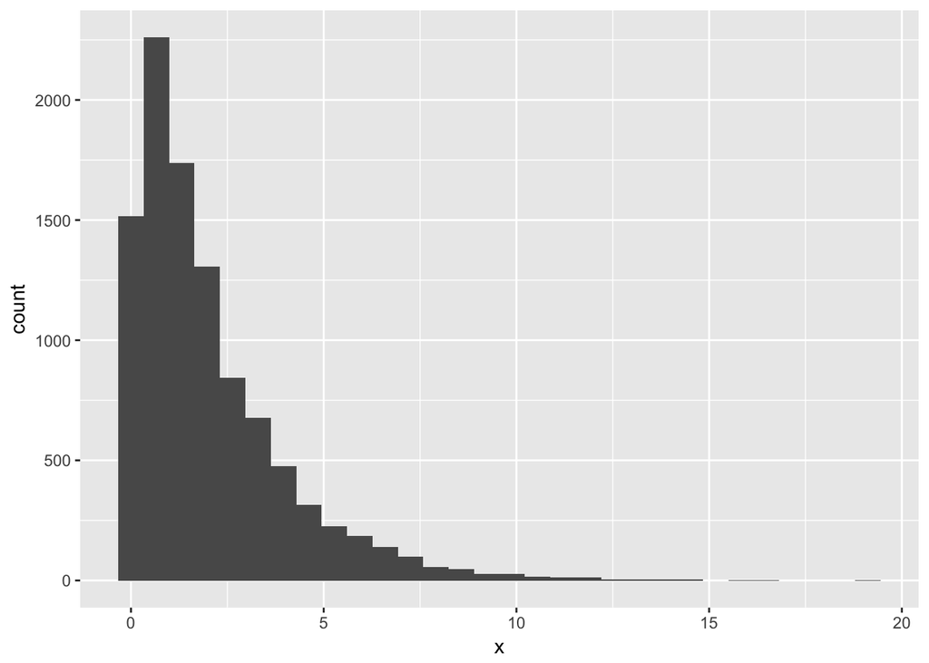

```r
n <- 10000
# look at ?rgamma to read about this function
gamma_samp <- tibble(x = rgamma(n, shape = 1, scale = 2))
gamma_samp %>% ggplot(mapping = aes(x = x)) + geom_histogram()
```

#### 2Q) What is the mean and standard deviation of your sample? They should both be close to 2 because for a gamma distribution: mean = shape x scale and variance = shape x scaleˆ2

```r
gamma_samp %>% summarise( mean = mean(x), std_devation = sd(x))
```

```
## # A tibble: 1 x 2
##    mean std_devation
##   <dbl>        <dbl>
## 1  2.03         2.00
```

#### 3Q) Pretend the distribution of our population of data looks like the plot above. Now take a sample of size n = 30 from a Gamma(1,2) distribution, plot the histogram or density curve, and calculate the mean and standard deviation.

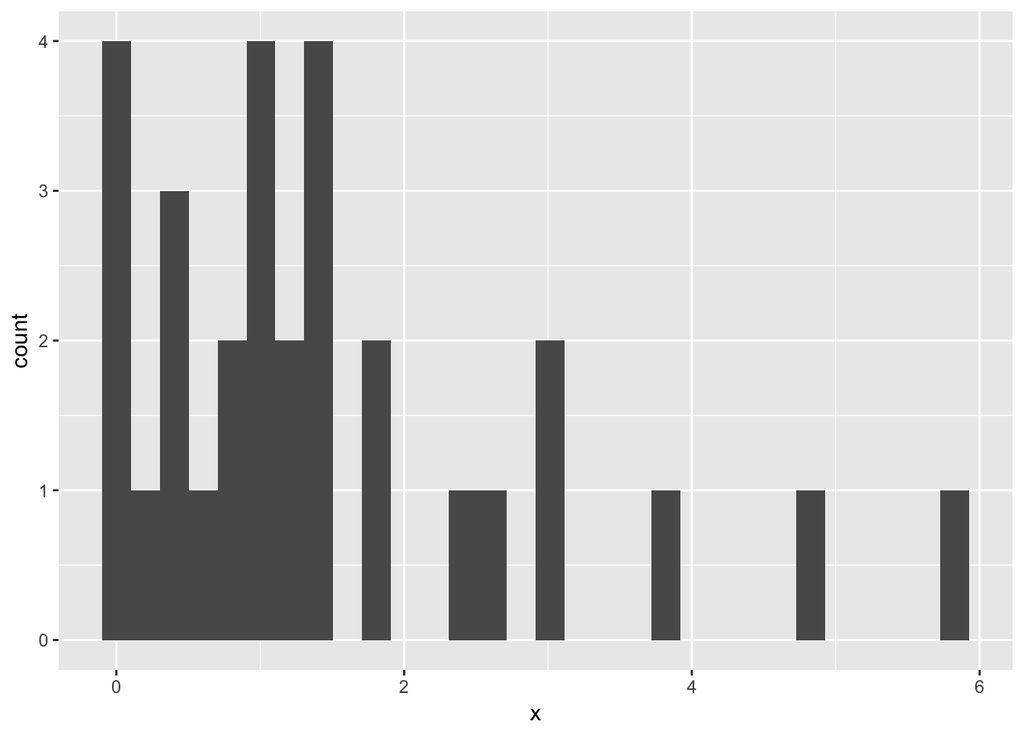

```r
gamma_samp_2 <- tibble(x = rgamma(30, shape = 1, scale = 2))

# Histogram of the new Sample
gamma_samp_2 %>% ggplot(mapping = aes(x = x)) + geom_histogram()
```

```r
# Mean and Standard deviation of the new sample
gamma_samp_2 %>% summarise( mean = mean(x), std_devation = sd(x))
```

```
## # A tibble: 1 x 2
##    mean std_devation
##   <dbl>        <dbl>
## 1  1.49         1.43
```

#### 4Q) Take a sample of size n = 30, again from the Gamma(1,2) distribution, calculate the mean, and assign it to a vector named mean_samp. Repeat this 10000 times!!!! The code below might help.

```r
# create a vector with 10000 NAs
mean_samp <- rep(NA, 10000)
# start a loop
for(i in 1:10000) {
g_samp <- rgamma(30, shape = 1, scale = 2)
mean_samp[i] <- mean(g_samp)
}
# Convert vector to a tibble
(mean_samp <- tibble(mean_samp))
```

```
## # A tibble: 10,000 x 1
##    mean_samp
##        <dbl>
##  1      2.92
##  2      2.79
##  3      2.19
##  4      1.59
##  5      2.28
##  6      2.10
##  7      1.84
##  8      2.00
##  9      1.57
## 10      2.47
## # ... with 9,990 more rows
```

#### 5Q) Make a histogram of your collection of means from above (mean_samp)

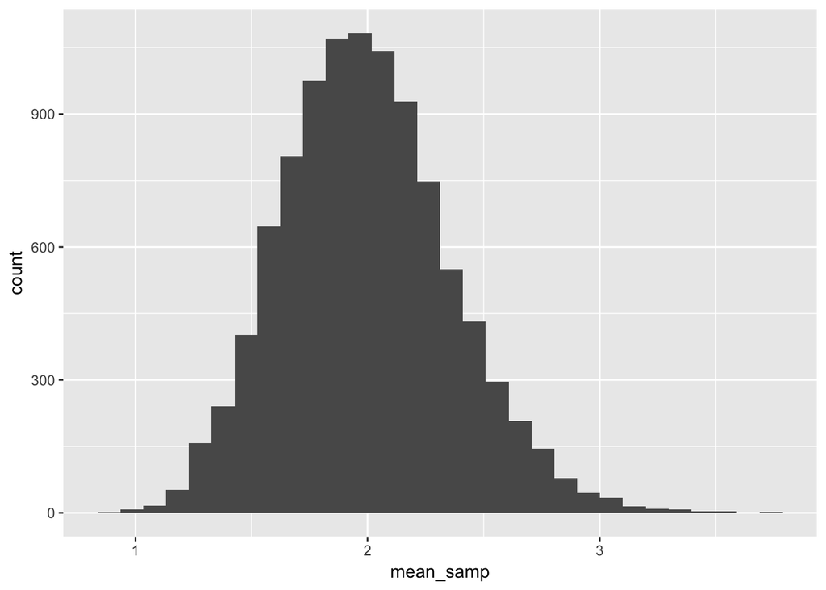

```r
# Histogram of collection of means
mean_samp %>% ggplot(mapping = aes(x = mean_samp)) + geom_histogram()
```

#### 6Q) Calculate the mean and standard deviation of all of your sample means.

```r
# Mean of mean sample

(mean <- mean(mean_samp$mean_samp))
```

```
## [1] 1.995195
```

```r
# standard deviation of sample
(sd <- sd(mean_samp$mean_samp))
```

```
## [1] 0.3628856
```

#### 7Q) Did anything surprise you about your answers to #6?

*NOTE* not answered.

#### 8Q) According to the Central Limit Theorem, the mean of your sampling distribution should be very close to 2, and the standard deviation of your sampling distribution should be close to √σ/n = √2/30 = 0.365. Repeat #4-#6, but now with a sample of size n = 300 instead. Do your results match up well with the theorem?

Yes, the results match up with the theorem.

```r
# create a vector with 10000 NAs
mean_samp <- rep(NA, 10000)
# start a loop
for(i in 1:10000) {
g_samp <- rgamma(300, shape = 1, scale = 2)
mean_samp[i] <- mean(g_samp)
}
# Convert vector to a tibble
(mean_samp <- tibble(mean_samp))
```

```
## # A tibble: 10,000 x 1
##    mean_samp
##        <dbl>
##  1      1.89
##  2      2.15
##  3      2.39
##  4      2.05
##  5      1.86
##  6      2.11
##  7      2.08
##  8      2.02
##  9      1.96
## 10      2.06
## # ... with 9,990 more rows
```

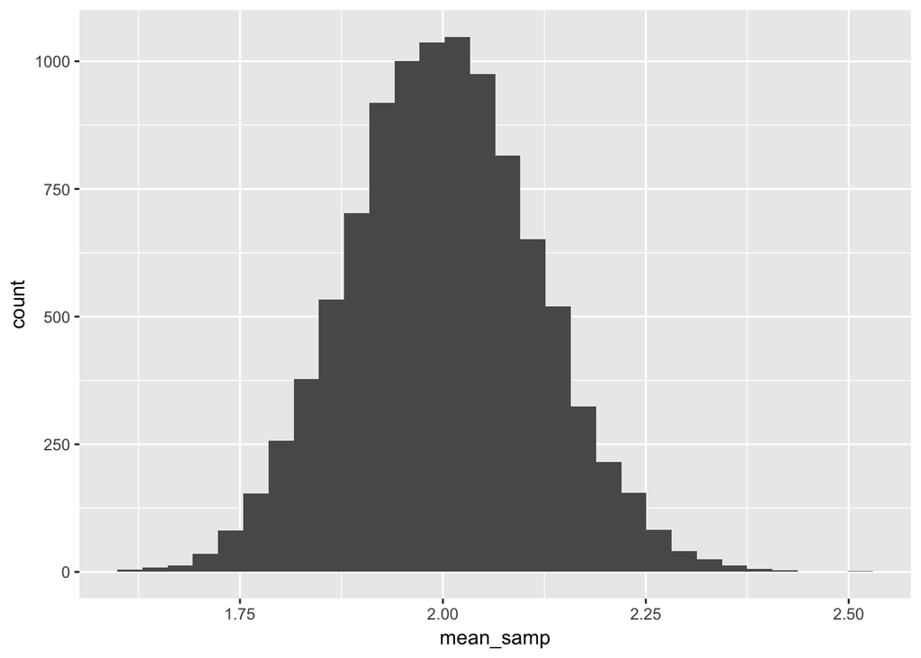

```r
# Histogram of collection of means for sample size 300
mean_samp %>% ggplot(mapping = aes(x = mean_samp)) + geom_histogram()
```

```r
# Mean of mean sample size 300
(mean <- mean(mean_samp$mean_samp))
```

```
## [1] 1.999834
```

```r
# standard deviation of sample size 300
(sd <- sd(mean_samp$mean_samp))
```

```
## [1] 0.1159681
```